# Lab 10: Biodiversity Databases and Community Phylogenetics

Jennifer Lin, GSI: Ixchel González

04/01/2020

# Integrative Biology 200

# Principles of Phylogenetics

# University of California, Berkeley

# 1 Introduction

This week we’ll briefly check out several different online databases that contain phylogenetic, specimen, and taxonomic information. We’ll also look at a few R packages that you can use to automate querying these resources. After, we will explore some methods for community phylogenetic analyses.

# 2 Phylogenetic Online Databases and Tools

## 2.1 TreeBASE

TreeBASE https://treebase.org is a repository of phylogenetic information, specifically user-submitted phylogenetic trees and the data used to generate them. Many studies upload their phylogenies and sequence matrices here, so they can be used or reanalyzed in future studies. Many journals require trees to be deposited in TreeBASE before publication.

Try searching TreeBASE for a phylogeny of a taxon that interests you.

## 2.2 Open Tree of Life

The Open Tree of Life (OTOL) http://opentreeoflife.org/ is a newer system that stores published phylogenies (like TreeBASE) but also synthesizes a constantly updated version of the entire tree of life that you can explore here: https://tree.opentreeoflife.org/.

Navigate the tree by clicking the nodes. Now, try searching OTOL for a phylogeny of the same taxon you searched TreeBASE for. Unlike TreeBASE, OTOL will deliver a taxonomic tree if a molecular phylogeny has not been uploaded for your group of interest.

### 2.2.1 rotl R Package

To programmatically query and access OTOL data install this R package:

```r
# install.packages("rotl")

library(rotl)

library(ape)
```

Now we can query a small part of the tree of life as it is currently known. To extract a portion of the tree, we first need to get the ott ids (Open Tree Taxonomy Identifiers) of the taxa we’re interested in:

```r
apes <- c("Pan", "Pongo", "Pan", "Gorilla", "Hylobates", "Hoolock", "Homo")

apes_resolved <- tnrs_match_names(apes)
apes_resolved
```

```
##   search_string unique_name approximate_match ott_id is_synonym          flags
## 1           pan         Pan             FALSE 417957      FALSE SIBLING_HIGHER
## 2         pongo       Pongo             FALSE 417949      FALSE
## 3       gorilla     Gorilla             FALSE 417969      FALSE SIBLING_HIGHER
## 4     hylobates   Hylobates             FALSE 166552      FALSE
## 5       hoolock     Hoolock             FALSE 712902      FALSE
## 6          homo        Homo             FALSE 770309      FALSE SIBLING_HIGHER
##   number_matches
## 1              2
## 2              2
## 3              1
## 4              1
## 5              1
## 6              1
```

Now we can get the tree with those tips:

```r
tree <- tol_induced_subtree(ott_ids=apes_resolved$ott_id)
```

```
##
Progress [----------------------------------] 0/13 (  0) ?s
Progress [================================] 13/13 (100)  0s
```

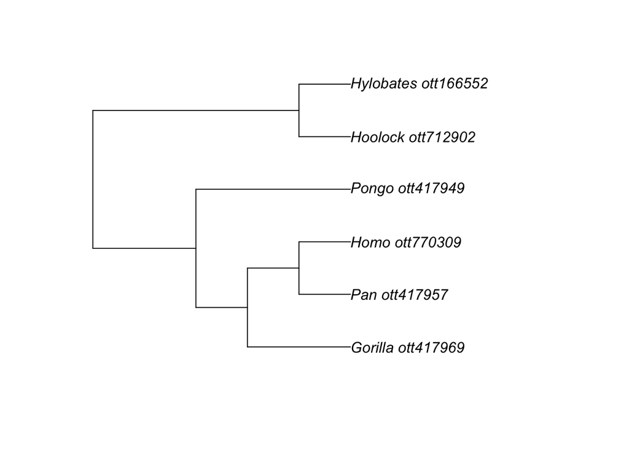

```r
plot(tree)
```

Let’s download a published tree by a former member of this class! Andrew Thornhill published a Myrtaceae tree that has been uploaded to the OTOL. First, get the ott id of Myrtaceae:

```r
myrtaceae_resolved <- tnrs_match_names("Myrtaceae")
```

Now get the subtree under the Myrtaceae node. It’s a big tree, so we’ll plot it without tip labels:

```r
tree <- tol_subtree(ott_id = myrtaceae_resolved$ott_id)
```

```
##
Progress [---------------------------------] 0/160 (  0) ?s
Progress [==============================] 160/160 (100)  0s
```

[output not shown]

[output cut: 11 more lines]

[output not shown]

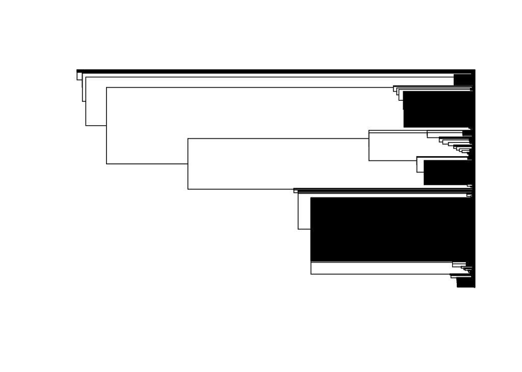

```r
plot(ladderize(tree), show.tip.label = F)
```

The more authors deposit their published phylogenies in the OTOL, the easier it will get for other researchers to access up-to-date phylogenies!

# 3 Specimen Online Databases and Tools

## 3.1 Berkeley Natural History Museums (BNHM)

The BNHM is a consortium of six natural history museums located here at UC Berkeley that house over 12 million specimens. If you are studying anything in California you will likely want to use BNHM resources. These are awesome resources, so please visit each website and learn what is available!

1. University and Jepson Herbaria: Consortium of California Herbaria http://ucjeps.berkeley.edu/consortium/
2. Museum of Vertebrate Zoology: VertNet http://www.vertnet.org/
3. Essig Museum of Entomology Collections https://essigdb.berkeley.edu/
4. University of California Museum of Paleontology Database http://ucmpdb.berkeley.edu/

## 3.2 Global Biodiverity Information Facilty (GBIF)

GBIF is an incredibly important resource that aggregates biodiversity data from institutions around the world and makes it all available through the internet. GBIF is useful for georeferenced distribution data, and contains both specimen and observation based data. Many of the BNHM resources listed above share their data in GBIF.

If you use GBIF data you should try to double check the quality of your data, as GBIF aggregates data from multiple sources, some of which have lower quality data than others. There are several sources with suggestions on how to best curate GBIF data.

### 3.2.1 GBIF Web Portal

Go to http://www.gbif.org/, and click on the Get Data pull down menu. Click on Species. Search for your taxon of interest. You should be able to view a map of all the georeferenced data for your taxon. How many georeferenced records are available? You can download all the records as a CSV or Darwin Core file.

### 3.2.2. rgbif R Package

What if we want to automate downloading GBIF data? Here’s a handy R package to programmatically access GBIF:

```r
# install.packages("rgbif")

library(rgbif)
```

Now let’s download occurence data for a taxon. This will take a minute or so:

```r
a_californica <- occ_search(scientificName="Asterella californica", limit=500)
```

We only downloaded the first 500 records, but how many total were found? 540

```r
a_californica
```

```
## Records found [540]
## Records returned [500]
## No. unique hierarchies [1]
## No. media records [500]
## No. facets [0]
## Args [limit=500, offset=0, scientificName=Asterella californica, fields=all]
## # A tibble: 500 x 142
##    key   scientificName decimalLatitude decimalLongitude issues datasetKey
##    <chr> <chr>                    <dbl>            <dbl> <chr>  <chr>
##  1 2543… Asterella cal…            32.8            -117. cdrou… 50c9509d-…
##  2 2543… Asterella cal…            32.7            -117. cdrou… 50c9509d-…
##  3 2557… Asterella cal…            37.4            -122. cdrou… 50c9509d-…
##  4 2557… Asterella cal…            37.9            -122. cdrou… 50c9509d-…
##  5 2557… Asterella cal…            37.9            -122. cdrou… 50c9509d-…
##  6 2563… Asterella cal…            32.9            -117. gass84 50c9509d-…
##  7 2563… Asterella cal…            33.1            -117. cdrou… 50c9509d-…
##  8 2563… Asterella cal…            33.6            -118. cdrou… 50c9509d-…
##  9 2563… Asterella cal…            33.7            -118. cdrou… 50c9509d-…
## 10 2563… Asterella cal…            32.8            -117. cdrou… 50c9509d-…
## # … with 490 more rows, and 136 more variables: publishingOrgKey <chr>,
## #   installationKey <chr>, publishingCountry <chr>, protocol <chr>,
## #   lastCrawled <chr>, lastParsed <chr>, crawlId <int>, extensions <chr>,
## #   basisOfRecord <chr>, taxonKey <int>, kingdomKey <int>, phylumKey <int>,
## #   classKey <int>, orderKey <int>, familyKey <int>, genusKey <int>,
## #   speciesKey <int>, acceptedTaxonKey <int>, acceptedScientificName <chr>,
## #   kingdom <chr>, phylum <chr>, order <chr>, family <chr>, genus <chr>,
## #   species <chr>, genericName <chr>, specificEpithet <chr>, taxonRank <chr>,
## #   taxonomicStatus <chr>, dateIdentified <chr>,
## #   coordinateUncertaintyInMeters <dbl>, stateProvince <chr>, year <int>,
## #   month <int>, day <int>, eventDate <chr>, modified <chr>,
## #   lastInterpreted <chr>, references <chr>, license <chr>, identifiers <chr>,
## #   facts <chr>, relations <chr>, geodeticDatum <chr>, class <chr>,
## #   countryCode <chr>, recordedByIDs <chr>, identifiedByIDs <chr>,
## #   country <chr>, rightsHolder <chr>, identifier <chr>,
## #   http...unknown.org.nick <chr>, verbatimEventDate <chr>, datasetName <chr>,
## #   verbatimLocality <chr>, collectionCode <chr>, gbifID <chr>,
## #   occurrenceID <chr>, taxonID <chr>, recordedBy <chr>, catalogNumber <chr>,
## #   http...unknown.org.occurrenceDetails <chr>, institutionCode <chr>,
## #   rights <chr>, eventTime <chr>, identificationID <chr>, name <chr>,
## #   recordedByIDs.type <chr>, recordedByIDs.value <chr>,
## #   identifiedByIDs.type <chr>, identifiedByIDs.value <chr>,
## #   occurrenceRemarks <chr>, informationWithheld <chr>,
## #   identificationRemarks <chr>, elevation <dbl>, continent <chr>,
## #   nomenclaturalStatus <chr>, recordNumber <chr>, nomenclaturalCode <chr>,
## #   locality <chr>, county <chr>, type <chr>, ownerInstitutionCode <chr>,
## #   bibliographicCitation <chr>, identifiedBy <chr>, collectionID <chr>,
## #   habitat <chr>, institutionID <chr>, endDayOfYear <chr>, language <chr>,
## #   preparations <chr>, startDayOfYear <chr>, verbatimElevation <chr>,
## #   elevationAccuracy <dbl>, individualCount <int>,
## #   http...unknown.org.recordId <chr>, otherCatalogNumbers <chr>,
## #   http...unknown.org.recordEnteredBy <chr>, higherGeography <chr>,
## #   dynamicProperties <chr>, …
```

Take a look at the first occurence:

```r
a_californica$data[1,]
```

```
## # A tibble: 1 x 142
##   key   scientificName decimalLatitude decimalLongitude issues datasetKey
##   <chr> <chr>                    <dbl>            <dbl> <chr>  <chr>
## 1 2543… Asterella cal…            32.8            -117. cdrou… 50c9509d-…
## # … with 136 more variables: publishingOrgKey <chr>, installationKey <chr>,
## #   publishingCountry <chr>, protocol <chr>, lastCrawled <chr>,
## #   lastParsed <chr>, crawlId <int>, extensions <chr>, basisOfRecord <chr>,
## #   taxonKey <int>, kingdomKey <int>, phylumKey <int>, classKey <int>,
## #   orderKey <int>, familyKey <int>, genusKey <int>, speciesKey <int>,
## #   acceptedTaxonKey <int>, acceptedScientificName <chr>, kingdom <chr>,
## #   phylum <chr>, order <chr>, family <chr>, genus <chr>, species <chr>,
## #   genericName <chr>, specificEpithet <chr>, taxonRank <chr>,
## #   taxonomicStatus <chr>, dateIdentified <chr>,
## #   coordinateUncertaintyInMeters <dbl>, stateProvince <chr>, year <int>,
## #   month <int>, day <int>, eventDate <chr>, modified <chr>,
## #   lastInterpreted <chr>, references <chr>, license <chr>, identifiers <chr>,
## #   facts <chr>, relations <chr>, geodeticDatum <chr>, class <chr>,
## #   countryCode <chr>, recordedByIDs <chr>, identifiedByIDs <chr>,
## #   country <chr>, rightsHolder <chr>, identifier <chr>,
## #   http...unknown.org.nick <chr>, verbatimEventDate <chr>, datasetName <chr>,
## #   verbatimLocality <chr>, collectionCode <chr>, gbifID <chr>,
## #   occurrenceID <chr>, taxonID <chr>, recordedBy <chr>, catalogNumber <chr>,
## #   http...unknown.org.occurrenceDetails <chr>, institutionCode <chr>,
## #   rights <chr>, eventTime <chr>, identificationID <chr>, name <chr>,
## #   recordedByIDs.type <chr>, recordedByIDs.value <chr>,
## #   identifiedByIDs.type <chr>, identifiedByIDs.value <chr>,
## #   occurrenceRemarks <chr>, informationWithheld <chr>,
## #   identificationRemarks <chr>, elevation <dbl>, continent <chr>,
## #   nomenclaturalStatus <chr>, recordNumber <chr>, nomenclaturalCode <chr>,
## #   locality <chr>, county <chr>, type <chr>, ownerInstitutionCode <chr>,
## #   bibliographicCitation <chr>, identifiedBy <chr>, collectionID <chr>,
## #   habitat <chr>, institutionID <chr>, endDayOfYear <chr>, language <chr>,
## #   preparations <chr>, startDayOfYear <chr>, verbatimElevation <chr>,
## #   elevationAccuracy <dbl>, individualCount <int>,
## #   http...unknown.org.recordId <chr>, otherCatalogNumbers <chr>,
## #   http...unknown.org.recordEnteredBy <chr>, higherGeography <chr>,
## #   dynamicProperties <chr>, …
```

We can get the latitude and longitude of the first record:

```r
a_californica$data[1,3]
```

```
## # A tibble: 1 x 1
##   decimalLatitude
##             <dbl>
## 1            32.8
```

```r
a_californica$data[1,4]
```

```
## # A tibble: 1 x 1
##   decimalLongitude
##              <dbl>
## 1            -117.
```

Let’s map the data using the R package ggplot2:

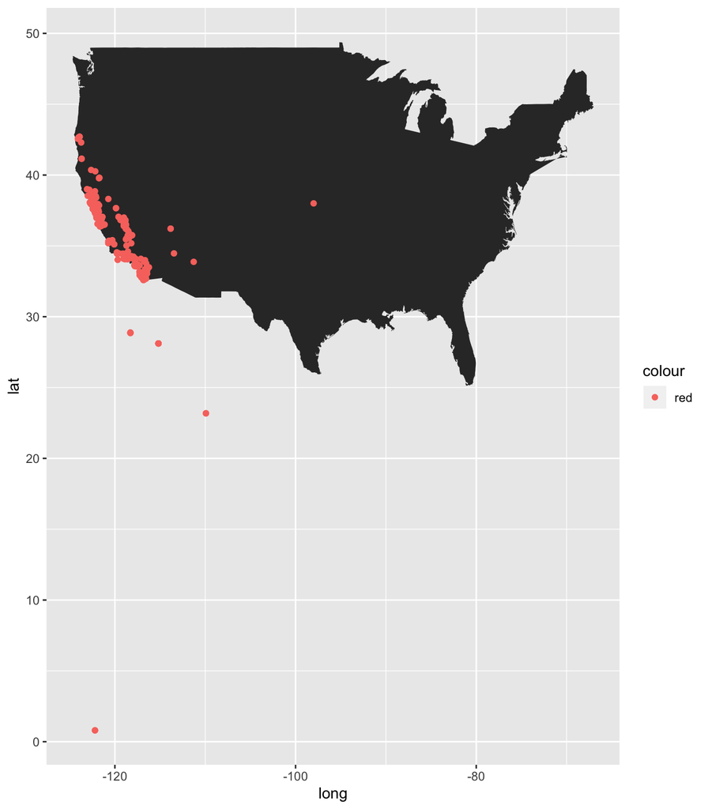

```r
library(ggplot2)

map <- map_data("usa")

ggplot() + geom_polygon(data = map, aes( x=long, y = lat)) +
  geom_point(a_californica$data, mapping = aes( x= decimalLongitude, y = decimalLatitude, col = "red"))
```

## Question 1

#### Do you see any problems with this distribution map? Do you trust the data? Why or why not?

## Answer 1

According ot the information I searhced online, Asterella californica occurs throughout the Coast Ranges, western Klamath Ranges, Sacramento Valley, west slope of the Sierra Nevada, coastal Southern California and the Channel Islands, Transverse and Peninsular Ranges, western Colorado Desert; east to Arizona, north to southwestern Oregon, and south to northern Baja California.

Most of the occurence records are located near the region mentioned above, which seems to be correct. However, the occurence record in the middle of US and other occurence records located on the ocean seem not right to me. The occurence record in the middle of US is very far way from other occurence records. In addition, there is only one record in that region. Thus, it may be another species which has similar morphology to A. californica. Other records located on the ocean are even more suspicious since there are no lands for A. californica to grow. It may be some errors generated when entering these records to the database.

## 3.3 BIEN Network

The BIEN network provides curated data on neotropical plants, including occurence data and trait data. If you are working with neotropical plants, check out their online portal or their [R package](https://github.com/bmaitner/RBIEN/blob/master/tutorials/RBIEN_tutorial.Rmd). [Click here](http://bien.nceas.ucsb.edu/) to learn more about the services they provide.

# 4 Taxonomic Databases and Tools

Taxonomy is crucial when studying biodiversity because all biological data is linked through the names we use. However taxon names and concepts change, and systems to resolve synonyms are necessary.

## 4.1 Integrated Taxonomic Information System (ITIS)

ITIS is a partnership of US, Mexican, and Canadian government agencies that provides a database that standardizes taxonomic names. For each scientific name, ITIS includes the authority (author and date), taxonomic rank, associated synonyms and vernacular names where available, a unique taxonomic serial number, data source information (publications, experts, etc.) and data quality indicators. ITIS is often used as the absolute source of taxonomic data for large-scale biodiversity projects. Browse some of the data here: http: //www.itis.gov/

## 4.2 Global Names Resolver (GNR)

Often researchers have a list of taxon names, and they simply want to check the spelling and get the most up-to-date synonyms of each name. Services like the GNR can help: http://resolver.globalnames.org/

## 4.3 taxize R Package

The websites above are immensely helpful tools, but often we would like to use a script to check taxon names instead of copying and pasting names into the website. The R package taxize uses the GNR (and many other taxonomic databases) to do this:

```r
# install.packages("taxize")

library(taxize)
```

Let’s check for a taxon name:

```r
mynames <- gnr_resolve(names="Helianthos annus")

head(mynames)
```

```
## # A tibble: 6 x 5
##   user_supplied_name submitted_name  matched_name     data_source_title    score
##   <chr>              <chr>           <chr>            <chr>                <dbl>
## 1 Helianthos annus   Helianthos ann… Helianthus annus uBio NameBank         0.75
## 2 Helianthos annus   Helianthos ann… Helianthus annu… Catalogue of Life     0.75
## 3 Helianthos annus   Helianthos ann… Helianthus annu… ITIS                  0.75
## 4 Helianthos annus   Helianthos ann… Helianthus annu… NCBI                  0.75
## 5 Helianthos annus   Helianthos ann… Helianthus annu… GRIN Taxonomy for P…  0.75
## 6 Helianthos annus   Helianthos ann… Helianthus annu… Union 4               0.75
```

Here we see that the name was misspelled, and the GNR recommended Helianthus annus instead. We can also get an accepted name from a synonym. First, get the taxonomic serial numbers (TSN) of the taxa from ITIS:

```r
mynames <- c("Helianthus annuus ssp. jaegeri",
            "Helianthus annuus ssp. lenticularis",
            "Helianthus annuus ssp. texanus")

tsn <- get_tsn(mynames, accepted = FALSE)
```

```
## ══  3 queries  ═══════════════
```

```
##
## Retrieving data for taxon 'Helianthus annuus ssp. jaegeri'
```

```
## ✓  Found:  Helianthus annuus ssp. jaegeri
```

```
##
## Retrieving data for taxon 'Helianthus annuus ssp. lenticularis'
```

```
## ✓  Found:  Helianthus annuus ssp. lenticularis
```

```
##
## Retrieving data for taxon 'Helianthus annuus ssp. texanus'
```

```
## ✓  Found:  Helianthus annuus ssp. texanus
## ══  Results  ═════════════════
##
## ● Total: 3
## ● Found: 3
## ● Not Found: 0
```

Now get the accepted names for each TSN:

```r
lapply(tsn, itis_acceptname)
```

```
## [[1]]
##   submittedtsn      acceptedname acceptedtsn author
## 1       525928 Helianthus annuus       36616     L.
##
## [[2]]
##   submittedtsn      acceptedname acceptedtsn author
## 1       525929 Helianthus annuus       36616     L.
##
## [[3]]
##   submittedtsn      acceptedname acceptedtsn author
## 1       525930 Helianthus annuus       36616     L.
```

The taxize package will do a lot of other handy taxonomic data wrangling, check out https://github.com/ropensci/taxize for more.

## Question 2

#### Use R to access GBIF data and send me a map of your favorite taxon’s distribution.

## Answer 2

Download occurence data for Sciurus carolinensis.

```r
s_carolinensis <- occ_search(scientificName="Sciurus carolinensis", limit=500)
```

We only downloaded the first 500 records, but how many total were found? 162239

```r
s_carolinensis
```

```
## Records found [162239]
## Records returned [500]
## No. unique hierarchies [1]
## No. media records [500]
## No. facets [0]
## Args [limit=500, offset=0, scientificName=Sciurus carolinensis, fields=all]
## # A tibble: 500 x 80
##    key   scientificName decimalLatitude decimalLongitude issues datasetKey
##    <chr> <chr>                    <dbl>            <dbl> <chr>  <chr>
##  1 2542… Sciurus carol…            40.8            -74.0 cdrou… 50c9509d-…
##  2 2542… Sciurus carol…            44.3            -78.3 cdrou… 50c9509d-…
##  3 2542… Sciurus carol…            39.0            -77.2 cdrou… 50c9509d-…
##  4 2542… Sciurus carol…            28.3            -81.4 cdrou… 50c9509d-…
##  5 2542… Sciurus carol…            38.8            -77.1 cdrou… 50c9509d-…
##  6 2542… Sciurus carol…            43.1            -87.9 cdrou… 50c9509d-…
##  7 2542… Sciurus carol…            39.0            -77.2 cdrou… 50c9509d-…
##  8 2542… Sciurus carol…            31.3            -94.7 gass84 50c9509d-…
##  9 2542… Sciurus carol…            48.8            -93.7 cdrou… 50c9509d-…
## 10 2543… Sciurus carol…            43.1            -87.9 cdrou… 50c9509d-…
## # … with 490 more rows, and 74 more variables: publishingOrgKey <chr>,
## #   installationKey <chr>, publishingCountry <chr>, protocol <chr>,
## #   lastCrawled <chr>, lastParsed <chr>, crawlId <int>, extensions <chr>,
## #   basisOfRecord <chr>, taxonKey <int>, kingdomKey <int>, phylumKey <int>,
## #   classKey <int>, orderKey <int>, familyKey <int>, genusKey <int>,
## #   speciesKey <int>, acceptedTaxonKey <int>, acceptedScientificName <chr>,
## #   kingdom <chr>, phylum <chr>, order <chr>, family <chr>, genus <chr>,
## #   species <chr>, genericName <chr>, specificEpithet <chr>, taxonRank <chr>,
## #   taxonomicStatus <chr>, dateIdentified <chr>,
## #   coordinateUncertaintyInMeters <dbl>, stateProvince <chr>, year <int>,
## #   month <int>, day <int>, eventDate <chr>, modified <chr>,
## #   lastInterpreted <chr>, references <chr>, license <chr>, identifiers <chr>,
## #   facts <chr>, relations <chr>, geodeticDatum <chr>, class <chr>,
## #   countryCode <chr>, recordedByIDs <chr>, identifiedByIDs <chr>,
## #   country <chr>, rightsHolder <chr>, identifier <chr>,
## #   http...unknown.org.nick <chr>, verbatimEventDate <chr>, datasetName <chr>,
## #   verbatimLocality <chr>, collectionCode <chr>, gbifID <chr>,
## #   occurrenceID <chr>, taxonID <chr>, recordedBy <chr>, catalogNumber <chr>,
## #   http...unknown.org.occurrenceDetails <chr>, institutionCode <chr>,
## #   rights <chr>, eventTime <chr>, identificationID <chr>, name <chr>,
## #   informationWithheld <chr>, occurrenceRemarks <chr>,
## #   infraspecificEpithet <chr>, recordedByIDs.type <chr>,
## #   recordedByIDs.value <chr>, identifiedByIDs.type <chr>,
## #   identifiedByIDs.value <chr>
```

Take a look at the first occurence:

```r
s_carolinensis$data[1,]
```

```
## # A tibble: 1 x 80
##   key   scientificName decimalLatitude decimalLongitude issues datasetKey
##   <chr> <chr>                    <dbl>            <dbl> <chr>  <chr>
## 1 2542… Sciurus carol…            40.8            -74.0 cdrou… 50c9509d-…
## # … with 74 more variables: publishingOrgKey <chr>, installationKey <chr>,
## #   publishingCountry <chr>, protocol <chr>, lastCrawled <chr>,
## #   lastParsed <chr>, crawlId <int>, extensions <chr>, basisOfRecord <chr>,
## #   taxonKey <int>, kingdomKey <int>, phylumKey <int>, classKey <int>,
## #   orderKey <int>, familyKey <int>, genusKey <int>, speciesKey <int>,
## #   acceptedTaxonKey <int>, acceptedScientificName <chr>, kingdom <chr>,
## #   phylum <chr>, order <chr>, family <chr>, genus <chr>, species <chr>,
## #   genericName <chr>, specificEpithet <chr>, taxonRank <chr>,
## #   taxonomicStatus <chr>, dateIdentified <chr>,
## #   coordinateUncertaintyInMeters <dbl>, stateProvince <chr>, year <int>,
## #   month <int>, day <int>, eventDate <chr>, modified <chr>,
## #   lastInterpreted <chr>, references <chr>, license <chr>, identifiers <chr>,
## #   facts <chr>, relations <chr>, geodeticDatum <chr>, class <chr>,
## #   countryCode <chr>, recordedByIDs <chr>, identifiedByIDs <chr>,
## #   country <chr>, rightsHolder <chr>, identifier <chr>,
## #   http...unknown.org.nick <chr>, verbatimEventDate <chr>, datasetName <chr>,
## #   verbatimLocality <chr>, collectionCode <chr>, gbifID <chr>,
## #   occurrenceID <chr>, taxonID <chr>, recordedBy <chr>, catalogNumber <chr>,
## #   http...unknown.org.occurrenceDetails <chr>, institutionCode <chr>,
## #   rights <chr>, eventTime <chr>, identificationID <chr>, name <chr>,
## #   informationWithheld <chr>, occurrenceRemarks <chr>,
## #   infraspecificEpithet <chr>, recordedByIDs.type <chr>,
## #   recordedByIDs.value <chr>, identifiedByIDs.type <chr>,
## #   identifiedByIDs.value <chr>
```

We can get the latitude and longitude of the first record:

```r
s_carolinensis$data[1,3]
```

```
## # A tibble: 1 x 1
##   decimalLatitude
##             <dbl>
## 1            40.8
```

```r
s_carolinensis$data[1,4]
```

```
## # A tibble: 1 x 1
##   decimalLongitude
##              <dbl>
## 1            -74.0
```

Let’s map the data using the R package ggplot2:

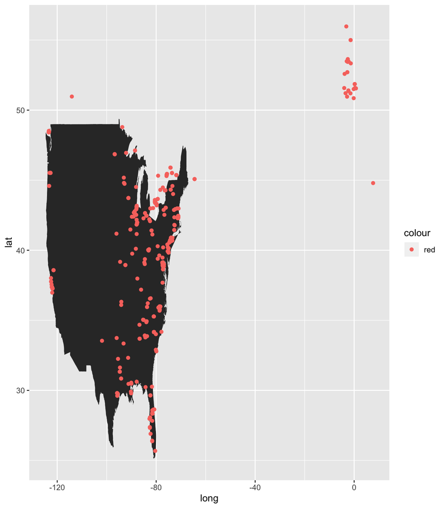

```r
library(ggplot2)

map <- map_data("usa")

ggplot() + geom_polygon(data = map, aes( x=long, y = lat)) +
  geom_point(s_carolinensis$data, mapping = aes( x= decimalLongitude, y = decimalLatitude, col = "red"))
```

# 5 Community Phylogenetics: PICANTE

Community phylogenetics incorporates phylogenetic structure into community ecology, and tries to understand how specific ecological communities are assembled. We’ll use the R package PICANTE to calculate community phylogenetic statistics and visualize the results on the phylogeny.

You need the PICANTE R package

```r
# install.packages("picante")

library(picante)
```

The package picante has many of the operations found in the program phylocom available from: www.phylodiversity.net/phylocom. The statistic we will focus on is NRI (Net Relatedness Index), which is similar to (Nearest Taxon Index). Both these statistics are defined in your [lecture notes](http://ib.berkeley.edu/courses/ib200/lect/mar20_DA.pdf). There are many other functions in the picante package for phylogenetic analysis of community ecology. If you are interested in these types of analyses then I would suggest that you read over the picante manual.

We will use some of the data that is already found in the picante package. This is the made up phylogenetic tree for our example. Let’s rename it ‘phy’.

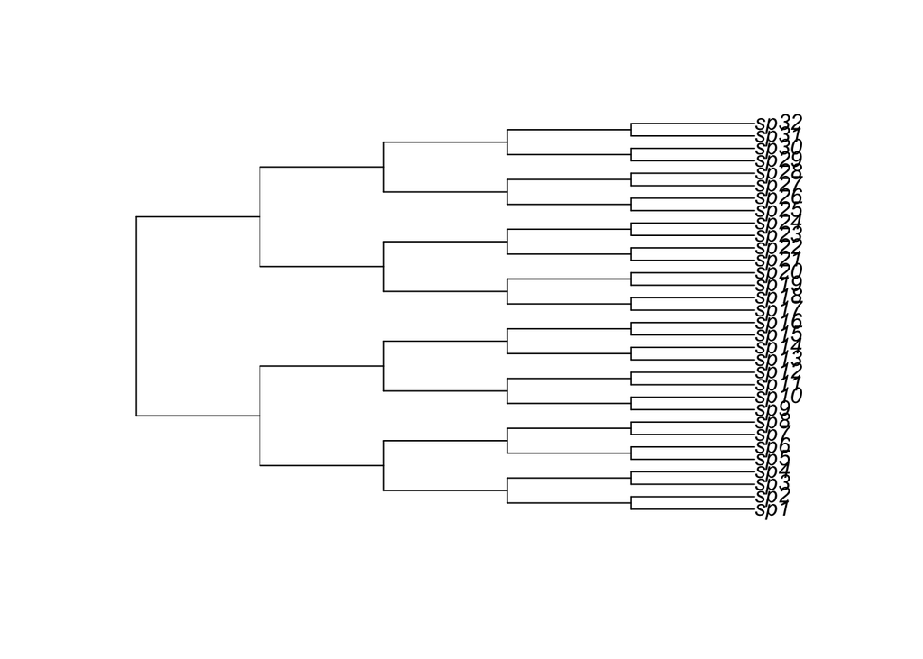

```r
data(phylocom)

phy <- phylocom$phylo

plot(phy)
```

This is a matrix of abundance data for the taxa in this tree from 6 different locations (communities). The names of species should match names in the phylogeny. Let’s rename this ‘samp’.

```r
samp <- phylocom$sample

samp
```

```
##         sp1 sp10 sp11 sp12 sp13 sp14 sp15 sp17 sp18 sp19 sp2 sp20 sp21 sp22
## clump1    1    0    0    0    0    0    0    0    0    0   1    0    0    0
## clump2a   1    2    2    2    0    0    0    0    0    0   1    0    0    0
## clump2b   1    0    0    0    0    0    0    2    2    2   1    2    0    0
## clump4    1    1    0    0    0    0    0    2    2    0   1    0    0    0
## even      1    0    0    0    1    0    0    1    0    0   0    0    1    0
## random    0    0    0    1    0    4    2    3    0    0   1    0    0    1
##         sp24 sp25 sp26 sp29 sp3 sp4 sp5 sp6 sp7 sp8 sp9
## clump1     0    0    0    0   1   1   1   1   1   1   0
## clump2a    0    0    0    0   1   1   0   0   0   0   2
## clump2b    0    0    0    0   1   1   0   0   0   0   0
## clump4     0    2    2    0   0   0   0   0   0   0   1
## even       0    1    0    1   0   0   1   0   0   0   1
## random     2    0    0    0   0   0   2   0   0   0   0
```

This is another matrix with discrete character data. Let’s rename this ‘traits’.

```r
traits <- phylocom$traits

traits
```

```
##      traitA traitB traitC traitD
## sp1       1      1      1      0
## sp2       1      1      2      0
## sp3       2      1      3      0
## sp4       2      1      4      0
## sp5       2      2      1      0
## sp6       2      2      2      0
## sp7       2      2      3      0
## sp8       2      2      4      0
## sp9       1      3      1      1
## sp10      1      3      2      1
## sp11      2      3      3      1
## sp12      2      3      4      1
## sp13      2      4      1      1
## sp14      2      4      2      1
## sp15      2      4      3      1
## sp16      2      4      4      1
## sp17      1      1      1      1
## sp18      1      1      2      1
## sp19      2      1      3      1
## sp20      2      1      4      1
## sp21      2      2      1      1
## sp22      2      2      2      1
## sp23      2      2      3      1
## sp24      2      2      4      1
## sp25      1      3      1      1
## sp26      1      3      2      1
## sp27      2      3      3      1
## sp28      2      3      4      1
## sp29      2      4      1      1
## sp30      2      4      2      1
## sp31      2      4      3      1
## sp32      2      4      4      1
```

## 5.1 Plotting Community Data

Let’s look at how the taxa found in those communities are distributed on our tree. First, let’s prune any taxa from our tree that are not also represented in our sample matrix (ie. also represented in our community).

```r
prunedphy <- prune.sample(samp, phy)

prunedphy
```

```
##
## Phylogenetic tree with 25 tips and 24 internal nodes.
##
## Tip labels:
##  sp1, sp2, sp3, sp4, sp5, sp6, ...
## Node labels:
##  A, B, C, D, E, F, ...
##
## Rooted; includes branch lengths.
```

We also need to make sure the species are arranged in the some order in the community data and the phylogeny. This is an important step - several functions in picante assume that the community or trait data and phylogeny data have species arranged in the same order, so it’s good to always make sure we’ve done so before running any analysis. The following command sorts the columns of samp to be in the same order as the tip labels of the phylogeny:

```r
samporder <- samp[, prunedphy$tip.label]

samporder
```

```
##         sp1 sp2 sp3 sp4 sp5 sp6 sp7 sp8 sp9 sp10 sp11 sp12 sp13 sp14 sp15 sp17
## clump1    1   1   1   1   1   1   1   1   0    0    0    0    0    0    0    0
## clump2a   1   1   1   1   0   0   0   0   2    2    2    2    0    0    0    0
## clump2b   1   1   1   1   0   0   0   0   0    0    0    0    0    0    0    2
## clump4    1   1   0   0   0   0   0   0   1    1    0    0    0    0    0    2
## even      1   0   0   0   1   0   0   0   1    0    0    0    1    0    0    1
## random    0   1   0   0   2   0   0   0   0    0    0    1    0    4    2    3
##         sp18 sp19 sp20 sp21 sp22 sp24 sp25 sp26 sp29
## clump1     0    0    0    0    0    0    0    0    0
## clump2a    0    0    0    0    0    0    0    0    0
## clump2b    2    2    2    0    0    0    0    0    0
## clump4     2    0    0    0    0    0    2    2    0
## even       0    0    0    1    0    0    1    0    1
## random     0    0    0    0    1    2    0    0    0
```

Let’s visualize our data. Now let’s see how taxa from the six communities in the Phylocom example data set are arranged on the tree. The following commands set up the layout of the plot to have 2 rows and 3 columns, and then plot a black dot for the species present in each of the six communities:

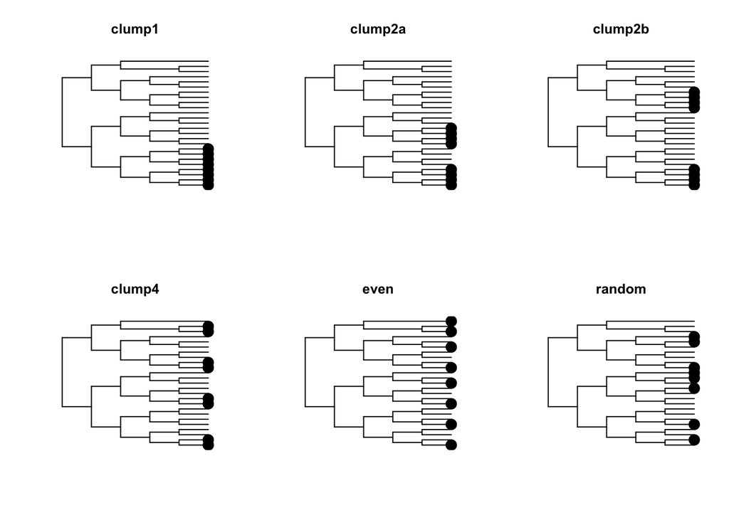

```r
par(mfrow = c(2, 3))

for (i in row.names(samporder)) {

  plot(prunedphy, show.tip.label = FALSE, main = i)

  tiplabels(tip = which(samporder[i, ] > 0), pch = 19, cex = 2)

}
```

Let’s also visualize the trait data that we have. We’ll plot the traits with a different color for each trait value:

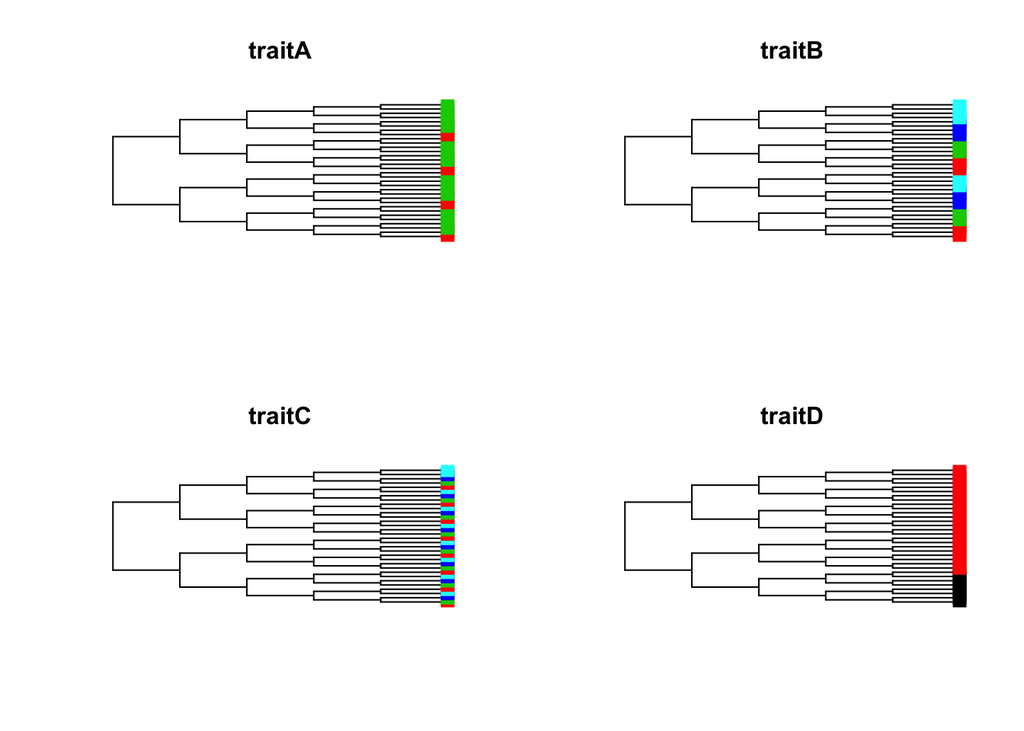

```r
par(mfrow = c(2, 2))

for (i in names(traits)) {

  plot(phy, show.tip.label = FALSE, main = i)

  tiplabels(pch = 22, col = traits[, i] + 1, bg = traits[,i] + 1, cex = 1.5)

}
```

## Question 3

#### Which of the traits **appear** to have the greatest phylogenetic signal?

## Answer 3

Phylogenetic signal is the tendency of related species to resemble each other more than species drawn at random from the same tree. Thus, traitD appears to gave the greatest phylogenetic signal.

## 5.2 Calculating NRI

Now we will calculate NRI (Net Relatedness Index) for our different communities. Calculating NTI (Nearest Taxon Index) is very similar - see the PICANTE manual for instructions if you are interested. Negative NRI and NTI values indicate a high level of phylogenetic overdispersion, and positive NRI and NTI values indicate phylogenetic clustering.

First we need to make a phylogenetic distance matrix.

```r
phydist <- cophenetic(phy)

phydist
```

```
##      sp1 sp2 sp3 sp4 sp5 sp6 sp7 sp8 sp9 sp10 sp11 sp12 sp13 sp14 sp15 sp16
## sp1    0   2   4   4   6   6   6   6   8    8    8    8    8    8    8    8
## sp2    2   0   4   4   6   6   6   6   8    8    8    8    8    8    8    8
## sp3    4   4   0   2   6   6   6   6   8    8    8    8    8    8    8    8
## sp4    4   4   2   0   6   6   6   6   8    8    8    8    8    8    8    8
## sp5    6   6   6   6   0   2   4   4   8    8    8    8    8    8    8    8
## sp6    6   6   6   6   2   0   4   4   8    8    8    8    8    8    8    8
## sp7    6   6   6   6   4   4   0   2   8    8    8    8    8    8    8    8
## sp8    6   6   6   6   4   4   2   0   8    8    8    8    8    8    8    8
## sp9    8   8   8   8   8   8   8   8   0    2    4    4    6    6    6    6
## sp10   8   8   8   8   8   8   8   8   2    0    4    4    6    6    6    6
## sp11   8   8   8   8   8   8   8   8   4    4    0    2    6    6    6    6
## sp12   8   8   8   8   8   8   8   8   4    4    2    0    6    6    6    6
## sp13   8   8   8   8   8   8   8   8   6    6    6    6    0    2    4    4
## sp14   8   8   8   8   8   8   8   8   6    6    6    6    2    0    4    4
## sp15   8   8   8   8   8   8   8   8   6    6    6    6    4    4    0    2
## sp16   8   8   8   8   8   8   8   8   6    6    6    6    4    4    2    0
## sp17  10  10  10  10  10  10  10  10  10   10   10   10   10   10   10   10
## sp18  10  10  10  10  10  10  10  10  10   10   10   10   10   10   10   10
## sp19  10  10  10  10  10  10  10  10  10   10   10   10   10   10   10   10
## sp20  10  10  10  10  10  10  10  10  10   10   10   10   10   10   10   10
## sp21  10  10  10  10  10  10  10  10  10   10   10   10   10   10   10   10
## sp22  10  10  10  10  10  10  10  10  10   10   10   10   10   10   10   10
## sp23  10  10  10  10  10  10  10  10  10   10   10   10   10   10   10   10
## sp24  10  10  10  10  10  10  10  10  10   10   10   10   10   10   10   10
## sp25  10  10  10  10  10  10  10  10  10   10   10   10   10   10   10   10
## sp26  10  10  10  10  10  10  10  10  10   10   10   10   10   10   10   10
## sp27  10  10  10  10  10  10  10  10  10   10   10   10   10   10   10   10
## sp28  10  10  10  10  10  10  10  10  10   10   10   10   10   10   10   10
## sp29  10  10  10  10  10  10  10  10  10   10   10   10   10   10   10   10
## sp30  10  10  10  10  10  10  10  10  10   10   10   10   10   10   10   10
## sp31  10  10  10  10  10  10  10  10  10   10   10   10   10   10   10   10
## sp32  10  10  10  10  10  10  10  10  10   10   10   10   10   10   10   10
##      sp17 sp18 sp19 sp20 sp21 sp22 sp23 sp24 sp25 sp26 sp27 sp28 sp29 sp30 sp31
## sp1    10   10   10   10   10   10   10   10   10   10   10   10   10   10   10
## sp2    10   10   10   10   10   10   10   10   10   10   10   10   10   10   10
## sp3    10   10   10   10   10   10   10   10   10   10   10   10   10   10   10
## sp4    10   10   10   10   10   10   10   10   10   10   10   10   10   10   10
## sp5    10   10   10   10   10   10   10   10   10   10   10   10   10   10   10
## sp6    10   10   10   10   10   10   10   10   10   10   10   10   10   10   10
```

[output cut: 44 more lines]

```
## sp18    8
## sp19    8
## sp20    8
## sp21    8
## sp22    8
## sp23    8
## sp24    8
## sp25    6
## sp26    6
## sp27    6
## sp28    6
## sp29    4
## sp30    4
## sp31    2
## sp32    0
```

Take a look at phydist. This is a matrix where the rows and columns are the taxa and the elements of the matrix are the phylogenetic distance between those pairs of taxa.

To calculate the NRI:

```r
ses.mpd(samporder, phydist,null.model="taxa.labels")
```

```
##         ntaxa  mpd.obs mpd.rand.mean mpd.rand.sd mpd.obs.rank  mpd.obs.z
## clump1      8 4.857143      8.287502   0.3547470          1.0 -9.6698742
## clump2a     8 6.000000      8.315244   0.3313030          1.0 -6.9882975
## clump2b     8 7.142857      8.317603   0.3245419          8.0 -3.6197063
## clump4      8 8.285714      8.319105   0.3105994        400.0 -0.1075035
## even        8 8.857143      8.326684   0.3208941        996.0  1.6530659
## random      8 8.428571      8.324896   0.3208228        533.5  0.3231538
##         mpd.obs.p runs
## clump1     0.0010  999
## clump2a    0.0010  999
## clump2b    0.0080  999
## clump4     0.4000  999
## even       0.9960  999
## random     0.5335  999
```

The rows are the communities. The columns are:

- ntaxa: Number of taxa in community
- mpd.obs: Observed mean pairwise distance (MPD) in community
- mpd.rand.mean: Mean MPD in null communities
- mpd.rand.sd: Standard deviation of MPD in null communities
- mpd.obs.rank: Rank of observed MPD vs. null communities
- mpd.obs.z: Standardized effect size of MPD vs. null communities (equivalent to -NRI)

The fifth column is the rank of the score against randomized communities; the sixth column is the negative NRI; and the seventh column is the one tailed p-value for significantly high NRI. Communities 1, 2 and 3 are significantly clustered and community 5 is significantly spread out.

## Question 4

#### Compare the results to the figures we made for each community – do the NRI values make sense? Explain how.

#### You can also use different null models to calculate these values. Here, we have indicated that our null model is the distance matrix shuffled across the taxa in the community. Feel free to explore other null models if you like.

## Answer 4

As mentioned before, negative NRI values indicate a high level of phylogenetic overdispersion, and positive NRI values indicate phylogenetic clustering. Because mpd.obs.z is equivalent to -NRI, we can rephrase the sentence above to “positive mpd.obs.z values indicate a high level of phylogenetic overdispersion, and negative mpd.obs.z values indicate phylogenetic clustering”.

We can see that clump1 has the most negative mpd.obs.z value (= most positive NRI value), which indicates high phylogenetic clustering. This is correct because clump1 only have one clump. As for clump2a, clump2b, to clump4, the mpd.obs.z values get larger and larger (NRI value get smaller and smaller), which means the level of phylogenetic overdispersion is getting higher and higher.

To sum up, the NRI values make sense in this scenario.

## 5.2 Calculating Phylogenetic Distance

We can also calculate measures of phylogenetic distance.

```r
traits <- traits[phy$tip.label, ]

multiPhylosignal(traits, phy)
```

```
##                K PIC.variance.obs PIC.variance.rnd.mean PIC.variance.P
## traitA 0.8905609       0.05396825             0.1259181          0.001
## traitB 2.9340184       0.10920635             0.8329285          0.001
## traitC 0.5149502       0.62222222             0.8395371          0.050
## traitD 4.3536696       0.01103943             0.1259887          0.001
##        PIC.variance.Z
## traitA      -3.676127
## traitB      -5.265029
## traitC      -1.633409
## traitD      -5.952393
```

## Question 5

#### Look at the column labeled ‘K’. This is Bloomberg’s K that we have previously discussed in lecture. K measures the phylogenetic signal of a trait – when K is greater than 1.0 there is more phylogenetic signal than expected under a Brownian motion model – closely related species resemble each other more than expected. When K is less than 1.0 it means closely related species differ more than would be expected under Brownian motion. Look at the results. What do these numbers mean? Which traits have strong phylogenetic signal? Do these values agree with your previous predictions?

## Question 5

#### What do these numbers mean?

According to the Picante package documentation:

The statistical significance of phylogenetic signal can be evaluated by comparing observed patterns of the variance of independent contrasts of the trait to a null model of shuffling taxa labels across the tips of the phylogeny.

The higher the K statistic, the more phylogenetic signal in a trait.

PIC.variance.P is the quantile of the observed phylogenetically independent contrast variance versus the null distribution, which can be used as a 1-tailed P-value to test for greater phylogenetic signal than expected. Traits with PIC.variance.P < 0.05 have non-random phylogenetic signal.

#### Which traits have strong phylogenetic signal?

TraitD and traitB have strong phylogenetic signal. According to the column labeld “K”, traitD and traitB have K values larger than 1, which indicates that closely related species resemble each other more than expected. As for traitA and traitC, they have K values smaller than 1, which indicates that closely related species differ more than would be expected under Brownian motion.

#### Do these values agree with your previous predictions?

**Send me your answers to questions 1-5, including any relevant figures.**

This lab was written by Will Freyman, David Ackerly, Nat Hallinan, Traci Grzymala and Carrie Tribble. Much of this was also taken from Community phylogenetic analysis with picante by Steven Kembel (skembel@uoregon.edu) http://picante.r-forge.r-project.org/picante-intro.pdf